# Kwartaalrapportage glastuinbouw

Q2 & Q3 2024

Auteur

HHSK - Johan van Tent

Publicatiedatum

15 oktober 2024

**Gewasbeschermingsmiddelen**

### Beschrijving gewasbeschermingsmiddelen

- Er zijn in Q2 en Q3 een aantal opvallende normoverschrijdingen. Imidacloprid is meerdere malen aangetroffen in hoge concentraties. Dergelijke concentraties zijn sinds 2018 niet meer gemeten. Ook fipronil en piperonylbutoxide blijven naar voren komen als forse normoverschrijders. Deze twee stoffen zijn beter in beeld gekomen doordat we lager kunnen meten.
- Imidacloprid is ook verantwoordelijk voor de grootste toxische effecten. De chronische toxiciteit van difenoconazool is ook een terugkerend probleem.
- Een groot deel van de normoverschrijdingen wordt geconstateerd met het pakket met extra lage detectiegrenzen. Deze zouden met het gewone pakket waarschijnlijk grotendeels zijn gemist. Dit geeft het vermoeden dat de problemen met gewasbeschermingsmiddelen in het glastuinbouwgebied groter zijn dan tot nu toe bleek uit de metingen.

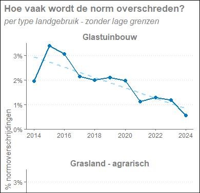

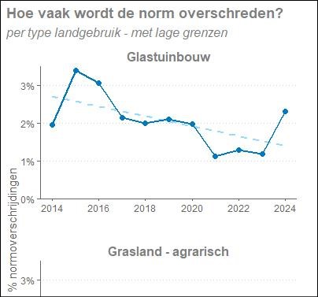

Zie voor een uitgebreider overzicht van alle metingen de [Rapportage gewasbeschermingsmiddelen HHSK](https://www.schielandendekrimpenerwaard.nl/kaart/waterkwaliteit/waterkwaliteitsrapportages/GBM_rapportage/).

### GBM - Overzichtstabel

| Stofnaam | Aantal metingen boven norm | Aantal metingen toxisch (> 0,5%) | Gemiddelde overschrijding | Hoogste overschrijding | Hoogste PAF (acuut) | Hoogste PAF (chronisch) |
| --- | --- | --- | --- | --- | --- | --- |
| Piperonyl-butoxide | 10 | 0 | 116,8 | 722,9 | 0.0% | 0.0% |
| Fipronil | 8 | 0 | 7,9 | 42,9 | 0.0% | 0.4% |
| Imidacloprid | 7 | 13 | 97,1 | 445,8 | 9.0% | 17.6% |
| Spiroxamine | 3 | 0 | 2,9 | 4,6 | 0.0% | 0.0% |
| Boscalid | 2 | 0 | 1,3 | 1,3 | 0.0% | 0.1% |
| Pendimethalin | 2 | 2 | 1,1 | 1,1 | 0.0% | 0.9% |
| Abamectine | 1 | 1 | 5,3 | 5,3 | 1.4% | 2.3% |
| Spinosad | 1 | 0 | 5,0 | 5,0 | — | — |
| Cyprodinil | 1 | 0 | 3,8 | 3,8 | 0.0% | 0.3% |
| Metazachloor | 1 | 0 | 3,5 | 3,5 | — | — |
| Spiromesifen | 1 | 0 | 2,5 | 2,5 | 0.0% | 0.2% |
| Teflubenzuron | 1 | 0 | 1,5 | 1,5 | — | — |
| Trans-fluoxastrobin | 1 | 0 | 1,3 | 1,3 | 0.0% | 0.0% |
| Acetamiprid | 1 | 1 | 1,2 | 1,2 | 1.0% | 0.2% |
| Azoxystrobin | 1 | 1 | 1,2 | 1,2 | 0.0% | 0.5% |
| Methoxyfenozide | 1 | 0 | 1,1 | 1,1 | 0.0% | 0.0% |
| Chlorantraniliprole | 0 | 1 | 0,0 | 0,0 | 0.1% | 1.1% |
| Diazinon | 0 | 1 | 0,0 | 0,0 | 0.0% | 0.7% |
| Difenoconazool | 0 | 4 | 0,0 | 0,0 | 0.0% | 4.5% |
| Diflubenzuron | 0 | 2 | 0,0 | 0,0 | 0.7% | 0.7% |
| Dimethenamide | 0 | 4 | 0,0 | 0,0 | 0.0% | 1.4% |
| Ethylparathion | 0 | 1 | 0,0 | 0,0 | 0.0% | 0.6% |
| Metolachloor | 0 | 1 | 0,0 | 0,0 | 0.0% | 0.7% |
| Trans-permethrin | 0 | 2 | 0,0 | 0,0 | 0.1% | 0.9% |

### GBM - Individuele metingen

| Stofnaam | Meetlocatie | Datum | Meetwaarde (ug/l) | Overschrijdingsfactor | PAF acuut | PAF chronisch |
| --- | --- | --- | --- | --- | --- | --- |
| Imidacloprid | S_1212 | 2024-08-16 | 3.7 | 445.7831325301205 | 0.09043372625322693 | 0.1762984519003341 |
| Imidacloprid | S_1212 | 2024-09-10 | 1.8 | 216.8674698795181 | 0.06502663562991295 | 0.1368854715308901 |
| Abamectine | S_1212 | 2024-04-12 | 0.0053 | 5.3 | 0.01416319650666491 | 0.0230329638159135 |
| Imidacloprid | S_1226 | 2024-08-16 | 0.079 | 9.518072289156626 | 0.01140464324700467 | 0.03517523342199155 |
| Acetamiprid | S_1226 | 2024-07-10 | 0.12 | 1.2 | 0.009609915965790826 | 0.002023543211142698 |
| Diflubenzuron | S_1212 | 2024-04-12 | 0.00024 | 0.06 | 0.00692484896811224 | 0.0071763213052092 |
| Imidacloprid | S_1226 | 2024-09-10 | 0.03 | 3.614457831325301 | 0.00598795739653403 | 0.0211185596914986 |
| Diflubenzuron | S_1212 | 2024-06-11 | 0.00016 | 0.04 | 0.005654350004530731 | 0.005631169394997778 |
| Imidacloprid | S_1212 | 2024-04-12 | 0.013 | 1.566265060240964 | 0.003294967504848702 | 0.0131246399203181 |
| Imidacloprid | S_1226 | 2024-07-10 | 0.012 | 1.44578313253012 | 0.003105631670366607 | 0.01251896694179652 |

[output cut: 54 more lines]

### GBM - Acute toxiciteit

[figure not shown]

### GBM - Chronische toxiciteit

[figure not shown]

### GBM - Percentage boven de norm

[figure not shown]

### GBM - Aantal stoffen boven de norm

[figure not shown]

### GBM - Overschrijdingsfactoren

[figure not shown]

### GBM - Aantal stoffen per monster

[figure not shown]

**Fosfaat en stikstof**

### Beschrijving nutriënten

- De concentraties stikstof en fosfaat waren in Q2 en Q3 in het glastuinbouwgebied vrij laag. De fosfaatconcentratie was in juni zelfs op hetzelfde niveau als elders in het gebied. Dit wijst erop dat de emissie van nutriënten uit het glastuinbouwgebied steeds verder afneemt.

[figure not shown]

### Fosfaat

[figure not shown]